# IC10-2-1: Data Preparation with Case 31

Employees Federal Credit Union

Author

Xueying Luo

Published

October 28, 2026

# 1 Import the SPSS file

```r
library(tidyverse)
library(haven)
library(labelled)
library(psych)
library(knitr)

# Read the raw SPSS data
data_raw <- read_sav("data/Case31.sav")
names(data_raw) <- tolower(names(data_raw))

# Check the number of rows, columns, and variable names
dim(data_raw)
```

```
[1] 128  34
```

```r
names(data_raw)
```

```
 [1] "q3"                        "q4"
 [3] "q5"                        "q6"
 [5] "q7"                        "q8"
 [7] "q9"                        "q10"
 [9] "q11"                       "q12"
[11] "q13"                       "q14"
[13] "q15"                       "q16"
[15] "q17"                       "q18"
[17] "q19"                       "q20"
[19] "q21"                       "q22"
[21] "q23"                       "q24"
[23] "q25"                       "q26"
[25] "q27"                       "q30"
[27] "q31"                       "q32"
[29] "q33"                       "q34"
[31] "q37"                       "overallemployeeperformace"
[33] "q38"                       "employeeperformance"
```

```r
head(data_raw)
```

```
# A tibble: 6 × 34
  q3        q4     q5    q6    q7       q8       q9      q10     q11     q12
  <dbl+lbl> <dbl+> <dbl> <dbl> <dbl+lb> <dbl+lb> <dbl+l> <dbl+l> <dbl+l> <dbl+l>
1 4         4      4     4      2 [Hig…  4 [Low] 3 [Abo… 1 [Exc… 1 [Yes] 1 [Yes]
2 4         4      4     4      3 [Ave…  3 [Ave… 3 [Abo… 2 [Goo… 1 [Yes] 1 [Yes]
3 4         4      4     4      3 [Ave… NA       3 [Abo… 1 [Exc… 1 [Yes] 1 [Yes]
4 4         4      3     4     NA        3 [Ave… 3 [Abo… 2 [Goo… 1 [Yes] 2 [No]
5 4         4      4     4      2 [Hig…  4 [Low] 3 [Abo… 2 [Goo… 1 [Yes] 3
6 4         4      4     4      3 [Ave…  3 [Ave… 3 [Abo… 2 [Goo… 1 [Yes] 2 [No]
# ℹ 24 more variables: q13 <dbl+lbl>, q14 <dbl+lbl>, q15 <dbl+lbl>,
#   q16 <dbl+lbl>, q17 <dbl+lbl>, q18 <dbl+lbl>, q19 <dbl+lbl>, q20 <dbl+lbl>,
#   q21 <dbl+lbl>, q22 <dbl+lbl>, q23 <dbl+lbl>, q24 <dbl+lbl>, q25 <dbl+lbl>,
#   q26 <dbl+lbl>, q27 <dbl+lbl>, q30 <dbl+lbl>, q31 <dbl+lbl>, q32 <dbl+lbl>,
#   q33 <dbl+lbl>, q34 <dbl+lbl>, q37 <dbl+lbl>,
#   overallemployeeperformace <dbl>, q38 <dbl+lbl>, employeeperformance <dbl>
```

# 2 Raw data and data entry

The case data were already provided as an SPSS file, so I did not need to enter the questionnaire responses manually in Excel. I kept the supplied `data/Case31.sav` unchanged and created a separate cleaned dataset. Although this file is called raw data in the assignment, it already includes some calculated employee-performance variables; I retain these for comparison.

# 3 Add respondent IDs

I give each respondent a unique sequential ID, as suggested in the new data-entry notes. These are row numbers, not the respondents’ original credit-union membership IDs. This has the same purpose as the `Res` variable shown in the notes.

```r
data <- data_raw |>
  mutate(respondent_id = row_number(), .before = 1)

head(data |> select(respondent_id, q3, q4, q5, q6))
```

```
# A tibble: 6 × 5
  respondent_id q3        q4        q5        q6
          <int> <dbl+lbl> <dbl+lbl> <dbl+lbl> <dbl+lbl>
1             1 4         4         4         4
2             2 4         4         4         4
3             3 4         4         4         4
4             4 4         4         3         4
5             5 4         4         4         4
6             6 4         4         4         4
```

# 4 Check measurement scales and variable descriptions

The measurement type depends on the question, not just the numeric code. In the SPSS class demonstration, agreement ratings are marked Scale for practical analysis. Single ordinal response questions still have ordered answer categories. The yes/no questions are Nominal.

```r
# These are the structured survey questions supplied in the SPSS file
questions <- c(paste0("q", 3:27), paste0("q", 30:34), "q37", "q38")

# Create a simple coding sheet
question_description <- c(
  "Employees are courteous", "Employees are helpful",
  "Employees are professional", "Employees are available",
  "Savings rates", "Borrowing rates", "Statement frequency",
  "Statement accuracy", "Statements are understandable",
  "Account information is confidential",
  "Regular share accounts", "Special subaccounts",
  "Christmas club accounts", "Individual retirement accounts",
  "MasterCard credit cards", "Signature loans", "New car loans",
  "Late model car loans", "Older model car loans",
  "Household goods/appliance loans", "Recreational loans",
  "Share collateralized loans", "IRA loans", "Line of credit loans",
  "Currently has a credit union loan",
  "Loan rates are lower than other institutions",
  "Financial information is kept confidential",
  "Loan applications are processed promptly",
  "Services meet members' needs", "Loan applications are simple",
  "Overall management and operations rating",
  "Lives in the headquarters area"
)

codebook <- tibble(
  variable = questions,
  description = question_description,
  measurement = "Ordinal"
)

# Classify yes/no responses as nominal
codebook$measurement[codebook$variable %in%
  c("q11", "q12", "q27", "q38")] <- "Nominal"

# Treats the five-point agreement items as scale variables
codebook$measurement[codebook$variable %in%
  c(paste0("q", 3:6), paste0("q", 30:34))] <- "Scale (5-point item)"

kable(codebook, caption = "Coding sheet and measurement levels")
```

Coding sheet and measurement levels

| variable | description | measurement |
| --- | --- | --- |
| q3 | Employees are courteous | Scale (5-point item) |
| q4 | Employees are helpful | Scale (5-point item) |
| q5 | Employees are professional | Scale (5-point item) |
| q6 | Employees are available | Scale (5-point item) |
| q7 | Savings rates | Ordinal |
| q8 | Borrowing rates | Ordinal |
| q9 | Statement frequency | Ordinal |
| q10 | Statement accuracy | Ordinal |
| q11 | Statements are understandable | Nominal |
| q12 | Account information is confidential | Nominal |
| q13 | Regular share accounts | Ordinal |
| q14 | Special subaccounts | Ordinal |
| q15 | Christmas club accounts | Ordinal |
| q16 | Individual retirement accounts | Ordinal |
| q17 | MasterCard credit cards | Ordinal |
| q18 | Signature loans | Ordinal |
| q19 | New car loans | Ordinal |
| q20 | Late model car loans | Ordinal |
| q21 | Older model car loans | Ordinal |
| q22 | Household goods/appliance loans | Ordinal |
| q23 | Recreational loans | Ordinal |
| q24 | Share collateralized loans | Ordinal |
| q25 | IRA loans | Ordinal |
| q26 | Line of credit loans | Ordinal |
| q27 | Currently has a credit union loan | Nominal |
| q30 | Loan rates are lower than other institutions | Scale (5-point item) |
| q31 | Financial information is kept confidential | Scale (5-point item) |
| q32 | Loan applications are processed promptly | Scale (5-point item) |
| q33 | Services meet members’ needs | Scale (5-point item) |
| q34 | Loan applications are simple | Scale (5-point item) |
| q37 | Overall management and operations rating | Ordinal |
| q38 | Lives in the headquarters area | Nominal |

# 5 Complete the response labels

I assign all possible categories from the questionnaire rather than only values observed in the sample. These labels do not change the original numeric answers.

```r
# Five-point agreement labels: Q3-Q6 and Q30-Q34
agree_labels <- c(
  "Strongly disagree" = 1, "Disagree" = 2,
  "Uncertain" = 3, "Agree" = 4, "Strongly agree" = 5
)

rate_labels <- c(
  "Very high" = 1, "High" = 2, "Average" = 3,
  "Low" = 4, "Very low" = 5, "No opinion" = 6
)

frequency_labels <- c(
  "Too often" = 1, "Very often" = 2, "About right" = 3,
  "Not often enough" = 4, "Never" = 5
)

accuracy_labels <- c(
  "Excellent" = 1, "Good" = 2, "Fair" = 3, "Poor" = 4
)

yes_no_labels <- c("Yes" = 1, "No" = 2)
yes_no_missing_labels <- c("Yes" = 1, "No" = 2, "No answer" = 3)

awareness_labels <- c(
  "Aware and have used" = 1,
  "Aware but have not used" = 2,
  "Unaware of service" = 3
)

overall_labels <- c(
  "Excellent" = 1, "Good" = 2, "Average" = 3,
  "Poor" = 4, "Very poor" = 5, "No opinion" = 6
)

# Apply the labels to the SPSS data
# Each named value is the original code from the questionnaire
data_labelled <- data |>
  set_value_labels(
    q3 = agree_labels, q4 = agree_labels, q5 = agree_labels,
    q6 = agree_labels, q30 = agree_labels, q31 = agree_labels,
    q32 = agree_labels, q33 = agree_labels, q34 = agree_labels,
    q7 = rate_labels, q8 = rate_labels,
    q9 = frequency_labels, q10 = accuracy_labels,
    q11 = yes_no_labels, q12 = yes_no_missing_labels,
    q27 = yes_no_labels, q38 = yes_no_labels,
    q13 = awareness_labels, q14 = awareness_labels,
    q15 = awareness_labels, q16 = awareness_labels,
    q17 = awareness_labels, q18 = awareness_labels,
    q19 = awareness_labels, q20 = awareness_labels,
    q21 = awareness_labels, q22 = awareness_labels,
    q23 = awareness_labels, q24 = awareness_labels,
    q25 = awareness_labels, q26 = awareness_labels,
    q37 = overall_labels
  )

# Verify that Q33 now has all five labels
val_labels(data_labelled$q33)
```

```
Strongly disagree          Disagree         Uncertain             Agree
                1                 2                 3                 4
   Strongly agree
                5
```

# 6 Examine missing values and questionable responses

A blank answer and a special code such as “No opinion” are not scores. The SPSS import may already convert user-defined missing codes to `NA`. I also check the raw numeric values so a special nonresponse code cannot accidentally enter the reverse coding.

```r
# Remove value labels only in the numeric working copy
analysis <- data_labelled |>
  mutate(across(all_of(questions), as.numeric))

# Count missing answers for each supplied question
missing_check <- tibble(
  question = questions,
  missing_n = sapply(analysis[questions], function(x) sum(is.na(x)))
)

kable(missing_check, caption = "System-missing answers by question")
```

System-missing answers by question

| question | missing_n |
| --- | --- |
| q3 | 0 |
| q4 | 0 |
| q5 | 0 |
| q6 | 0 |
| q7 | 10 |
| q8 | 21 |
| q9 | 0 |
| q10 | 0 |
| q11 | 0 |
| q12 | 0 |
| q13 | 0 |
| q14 | 0 |
| q15 | 0 |
| q16 | 0 |
| q17 | 0 |
| q18 | 0 |
| q19 | 0 |
| q20 | 0 |
| q21 | 0 |
| q22 | 0 |
| q23 | 0 |
| q24 | 0 |
| q25 | 0 |
| q26 | 0 |
| q27 | 0 |
| q30 | 0 |
| q31 | 0 |
| q32 | 0 |
| q33 | 0 |
| q34 | 0 |
| q37 | 7 |
| q38 | 0 |

```r
# Flag, but do not delete, respondents selecting all fives on Q3-Q6
all_fives <- with(analysis, q3 == 5 & q4 == 5 & q5 == 5 & q6 == 5)
sum(all_fives, na.rm = TRUE)
```

```
[1] 25
```

## 6.1 Check usable responses

The data-entry notes recommend checking for incomplete questionnaires and repeated answers before deciding which responses are usable. I will flag potential issues. Responses such as “No opinion” and “No answer” are treated as missing when checking completeness.

```r
# Make a copy for checking completeness
quality_answers <- analysis[questions]

# Treat "No opinion" as missing
for (v in c("q7", "q8", "q37")) {
  quality_answers[[v]] <- ifelse(
    quality_answers[[v]] == 6,
    NA, quality_answers[[v]]
  )
}

# Treat "No answer" as missing
for (v in c("q11", "q12", "q27", "q38")) {
  quality_answers[[v]] <- ifelse(
    quality_answers[[v]] == 3,
    NA, quality_answers[[v]]
  )
}

# Count unanswered questions for each respondent
missing_per_person <- rowSums(is.na(quality_answers))

# Check repeated highest ratings on Q3-Q6
all_fives <- analysis$q3 == 5 &
             analysis$q4 == 5 &
             analysis$q5 == 5 &
             analysis$q6 == 5

# Summarize response quality
screening_summary <- tibble(
  check = c(
    "Records supplied",
    "Respondents missing more than half of the supplied questions",
    "Respondents with at least one missing or no-answer response",
    "Respondents choosing 5 for each of Q3-Q6"
  ),
  number = c(
    nrow(analysis),
    sum(missing_per_person > length(questions) / 2),
    sum(missing_per_person > 0),
    sum(all_fives, na.rm = TRUE)
  )
)

kable(screening_summary,
      caption = "Initial response-quality screening")
```

Initial response-quality screening

| check | number |
| --- | --- |
| Records supplied | 128 |
| Respondents missing more than half of the supplied questions | 0 |
| Respondents with at least one missing or no-answer response | 43 |
| Respondents choosing 5 for each of Q3-Q6 | 25 |

Next, I check whether any observed numeric values fall outside the questionnaire’s permitted response range. This checks possible input errors without editing the original responses. Codes for “No opinion” and “No answer” are allowed during range checking but treated as missing when appropriate for analysis.

```r
# Set the maximum permitted code for each question
range_check <- tibble(
  question = questions,
  maximum = 5
)

# Questions with "No opinion" coded as 6
range_check$maximum[
  range_check$question %in% c("q7", "q8", "q37")
] <- 6

# Yes/No questions with "No answer" coded as 3
range_check$maximum[
  range_check$question %in% c("q11", "q12", "q27", "q38")
] <- 3

# Service awareness questions use codes 1-3
range_check$maximum[
  range_check$question %in% paste0("q", 13:26)
] <- 3

# Q10 uses a four-point scale
range_check$maximum[
  range_check$question == "q10"
] <- 4

# Count values outside the permitted range
range_check$invalid_n <- 0

for (i in 1:nrow(range_check)) {
  v <- range_check$question[i]
  upper <- range_check$maximum[i]

  range_check$invalid_n[i] <- sum(
    !is.na(analysis[[v]]) &
      !(analysis[[v]] %in% 1:upper)
  )
}

kable(range_check,
      caption = "Range checks for all questions")
```

Range checks for all questions

| question | maximum | invalid_n |
| --- | --- | --- |
| q3 | 5 | 0 |
| q4 | 5 | 0 |
| q5 | 5 | 0 |
| q6 | 5 | 0 |
| q7 | 6 | 0 |
| q8 | 6 | 0 |
| q9 | 5 | 0 |
| q10 | 4 | 0 |
| q11 | 3 | 0 |
| q12 | 3 | 0 |
| q13 | 3 | 0 |
| q14 | 3 | 0 |
| q15 | 3 | 0 |
| q16 | 3 | 0 |
| q17 | 3 | 0 |
| q18 | 3 | 0 |
| q19 | 3 | 0 |
| q20 | 3 | 0 |
| q21 | 3 | 0 |
| q22 | 3 | 0 |
| q23 | 3 | 0 |
| q24 | 3 | 0 |
| q25 | 3 | 0 |
| q26 | 3 | 0 |
| q27 | 3 | 0 |
| q30 | 5 | 0 |
| q31 | 5 | 0 |
| q32 | 5 | 0 |
| q33 | 5 | 0 |
| q34 | 5 | 0 |
| q37 | 6 | 0 |
| q38 | 3 | 0 |

# 7 Reverse-code the class-specified questions

I reverse the specified items so that larger new scores represent higher response categories. For Q7, Q8, and Q37, the special value 6 means No opinion, not zero. I use `ifelse()` to keep it missing. I create new columns and preserve the original questions.

```r
analysis <- analysis |>
  mutate(
    q7r = ifelse(q7 %in% 1:5, 6 - q7, NA),
    q8r = ifelse(q8 %in% 1:5, 6 - q8, NA),
    q9r = ifelse(q9 %in% 1:5, 6 - q9, NA),
    q10r = ifelse(q10 %in% 1:4, 5 - q10, NA),
    q13r = ifelse(q13 %in% 1:3, 4 - q13, NA),
    q14r = ifelse(q14 %in% 1:3, 4 - q14, NA),
    q15r = ifelse(q15 %in% 1:3, 4 - q15, NA),
    q16r = ifelse(q16 %in% 1:3, 4 - q16, NA),
    q17r = ifelse(q17 %in% 1:3, 4 - q17, NA),
    q18r = ifelse(q18 %in% 1:3, 4 - q18, NA),
    q19r = ifelse(q19 %in% 1:3, 4 - q19, NA),
    q20r = ifelse(q20 %in% 1:3, 4 - q20, NA),
    q21r = ifelse(q21 %in% 1:3, 4 - q21, NA),
    q22r = ifelse(q22 %in% 1:3, 4 - q22, NA),
    q23r = ifelse(q23 %in% 1:3, 4 - q23, NA),
    q24r = ifelse(q24 %in% 1:3, 4 - q24, NA),
    q25r = ifelse(q25 %in% 1:3, 4 - q25, NA),
    q26r = ifelse(q26 %in% 1:3, 4 - q26, NA),
    q37r = ifelse(q37 %in% 1:5, 6 - q37, NA),
    q12_clean = ifelse(q12 %in% 1:2, q12, NA)
  )

# Verify the new and original variables side by side
analysis |>
  select(respondent_id, q7, q7r, q8, q8r, q9, q9r,
         q10, q10r, q13, q13r, q37, q37r) |>
  head(8) |>
  kable(caption = "Original and recoded values")
```

Original and recoded values

| respondent_id | q7 | q7r | q8 | q8r | q9 | q9r | q10 | q10r | q13 | q13r | q37 | q37r |
| --- | --- | --- | --- | --- | --- | --- | --- | --- | --- | --- | --- | --- |
| 1 | 2 | 4 | 4 | 2 | 3 | 3 | 1 | 4 | 1 | 3 | 2 | 4 |
| 2 | 3 | 3 | 3 | 3 | 3 | 3 | 2 | 3 | 3 | 1 | 2 | 4 |
| 3 | 3 | 3 | NA | NA | 3 | 3 | 1 | 4 | 3 | 1 | 3 | 3 |
| 4 | NA | NA | 3 | 3 | 3 | 3 | 2 | 3 | 2 | 2 | NA | NA |
| 5 | 2 | 4 | 4 | 2 | 3 | 3 | 2 | 3 | 3 | 1 | 2 | 4 |
| 6 | 3 | 3 | 3 | 3 | 3 | 3 | 2 | 3 | 2 | 2 | 3 | 3 |
| 7 | 2 | 4 | 3 | 3 | 3 | 3 | 1 | 4 | 2 | 2 | 1 | 5 |
| 8 | 3 | 3 | 3 | 3 | 3 | 3 | 1 | 4 | 2 | 2 | 2 | 4 |

The new service-awareness codes are 1 = unaware, 2 = aware but not used, 3 = aware and used. For Q7–Q8, the new rate codes run from 1 = very low to 5 = very high. Higher rates are not necessarily higher satisfaction, particularly for borrowing costs.

# 8 Run frequencies

Frequency checks help identify coding errors and describe how many members selected each category. This simple loop uses `table()`, which works for every supplied question. I save the complete results for reference and display selected questions in the report.

```r
frequencies <- data.frame()

for (v in questions) {
  freq <- as.data.frame(table(analysis[[v]], useNA = "ifany"))
  names(freq) <- c("response", "n")
  freq$response <- as.character(freq$response)
  freq$question <- v
  freq$percent <- round(100 * freq$n / nrow(analysis), 1)
  frequencies <- rbind(frequencies, freq)
}

frequencies |>
  filter(question %in% c("q7", "q8", "q12", "q37", "q38")) |>
  select(question, response, n, percent) |>
  kable(caption = "Selected original-response frequencies")
```

Selected original-response frequencies

| question | response | n | percent |
| --- | --- | --- | --- |
| q7 | 2 | 22 | 17.2 |
| q7 | 3 | 83 | 64.8 |
| q7 | 4 | 12 | 9.4 |
| q7 | 5 | 1 | 0.8 |
| q7 | NA | 10 | 7.8 |
| q8 | 1 | 4 | 3.1 |
| q8 | 2 | 26 | 20.3 |
| q8 | 3 | 59 | 46.1 |
| q8 | 4 | 17 | 13.3 |
| q8 | 5 | 1 | 0.8 |
| q8 | NA | 21 | 16.4 |
| q12 | 1 | 74 | 57.8 |
| q12 | 2 | 32 | 25.0 |
| q12 | 3 | 22 | 17.2 |
| q37 | 1 | 31 | 24.2 |
| q37 | 2 | 71 | 55.5 |
| q37 | 3 | 16 | 12.5 |
| q37 | 4 | 2 | 1.6 |
| q37 | 5 | 1 | 0.8 |
| q37 | NA | 7 | 5.5 |
| q38 | 1 | 57 | 44.5 |
| q38 | 2 | 71 | 55.5 |

# 9 Reliability analysis

The professor demonstrates `psych::alpha()` for Q3–Q6, the four questions about employees being courteous, helpful, professional, and available. These are intended to reflect employee proficiency. The Q30–Q34 agreement questions address several aspects of the credit union; I examine their reliability but do not assume they form one construct.

```r
employee_items <- analysis |>
  select(q3, q4, q5, q6)

other_attitude_items <- analysis |>
  select(q30, q31, q32, q33, q34)

# Cronbach's alpha (as demonstrated in the video)
employee_alpha <- psych::alpha(employee_items)
other_alpha <- psych::alpha(other_attitude_items)

tibble(
  items = c("Q3-Q6: employee proficiency", "Q30-Q34: other attitudes"),
  cronbach_alpha = round(c(employee_alpha$total$raw_alpha,
                           other_alpha$total$raw_alpha), 3)
) |>
  kable(caption = "Reliability of the two item groups")
```

Reliability of the two item groups

| items | cronbach_alpha |
| --- | --- |
| Q3-Q6: employee proficiency | 0.866 |
| Q30-Q34: other attitudes | 0.539 |

```r
# Alpha if one employee question is removed
employee_alpha$alpha.drop[, "raw_alpha", drop = FALSE]
```

```
   raw_alpha
q3 0.8524511
q4 0.7853483
q5 0.8236986
q6 0.8529418
```

The Q3–Q6 alpha should be about 0.866, which exceeds the 0.70 classroom guideline. The Q30–Q34 alpha should be about 0.539, which is relatively low. A weak alpha and mixed question meanings are reasons not to create a single Q30–Q34 composite.

# 10 Exploratory factor analysis

I check a one-factor solution without rotation, review factor loadings, and use a scree plot to look for a dominant component.

```r
# One factor, no rotation
employee_factor <- psych::fa(employee_items, nfactors = 1,
                              rotate = "none")
employee_factor
```

```
Factor Analysis using method =  minres
Call: psych::fa(r = employee_items, nfactors = 1, rotate = "none")
Standardized loadings (pattern matrix) based upon correlation matrix
    MR1   h2   u2 com
q3 0.72 0.52 0.48   1
q4 0.92 0.85 0.15   1
q5 0.79 0.63 0.37   1
q6 0.73 0.53 0.47   1

                MR1
SS loadings    2.53
Proportion Var 0.63

Mean item complexity =  1
Test of the hypothesis that 1 factor is sufficient.

df null model =  6  with the objective function =  2.11 with Chi Square =  263.61
df of  the model are 2  and the objective function was  0.1

The root mean square of the residuals (RMSR) is  0.05
The df corrected root mean square of the residuals is  0.08

The harmonic n.obs is  128 with the empirical chi square  1.67  with prob <  0.43
The total n.obs was  128  with Likelihood Chi Square =  12.72  with prob <  0.0017

Tucker Lewis Index of factoring reliability =  0.874
RMSEA index =  0.204  and the 90 % confidence intervals are  0.108 0.32
BIC =  3.01
Fit based upon off diagonal values = 0.99
Measures of factor score adequacy
                                                   MR1
Correlation of (regression) scores with factors   0.95
Multiple R square of scores with factors          0.91
Minimum correlation of possible factor scores     0.81
```

```r
# A second exploratory check for Q30-Q34
other_factor <- psych::fa(other_attitude_items, nfactors = 1,
                           rotate = "none")
other_factor
```

```
Factor Analysis using method =  minres
Call: psych::fa(r = other_attitude_items, nfactors = 1, rotate = "none")
Standardized loadings (pattern matrix) based upon correlation matrix
     MR1    h2   u2 com
q30 0.40 0.161 0.84   1
q31 0.38 0.144 0.86   1
q32 0.79 0.618 0.38   1
q33 0.29 0.087 0.91   1
q34 0.35 0.126 0.87   1

                MR1
SS loadings    1.14
Proportion Var 0.23

Mean item complexity =  1
Test of the hypothesis that 1 factor is sufficient.

df null model =  10  with the objective function =  0.46 with Chi Square =  56.72
df of  the model are 5  and the objective function was  0.11

The root mean square of the residuals (RMSR) is  0.08
The df corrected root mean square of the residuals is  0.11

The harmonic n.obs is  128 with the empirical chi square  8.44  with prob <  0.13
The total n.obs was  128  with Likelihood Chi Square =  13.19  with prob <  0.022

Tucker Lewis Index of factoring reliability =  0.647
RMSEA index =  0.113  and the 90 % confidence intervals are  0.04 0.19
BIC =  -11.07
Fit based upon off diagonal values = 0.86
Measures of factor score adequacy
                                                   MR1
Correlation of (regression) scores with factors   0.83
Multiple R square of scores with factors          0.69
Minimum correlation of possible factor scores     0.38
```

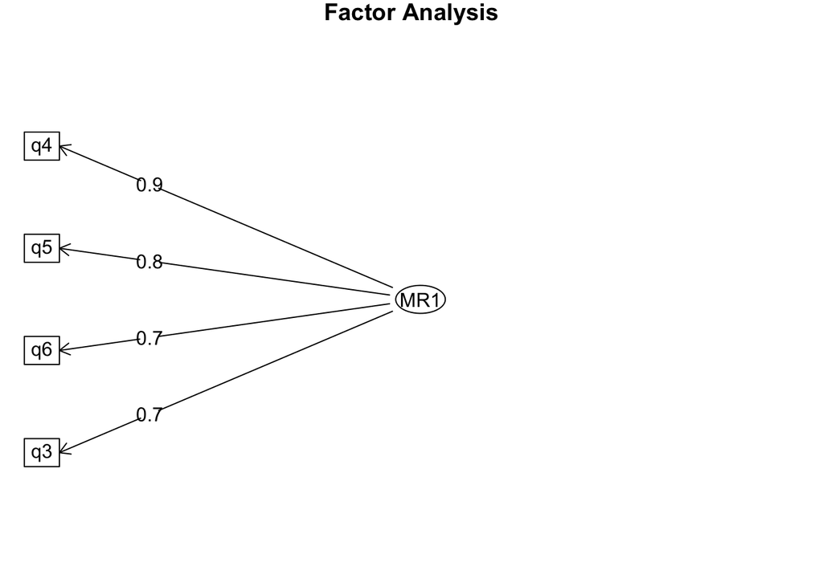

```r
# Factor diagram shown in the video
psych::fa.diagram(employee_factor)
```

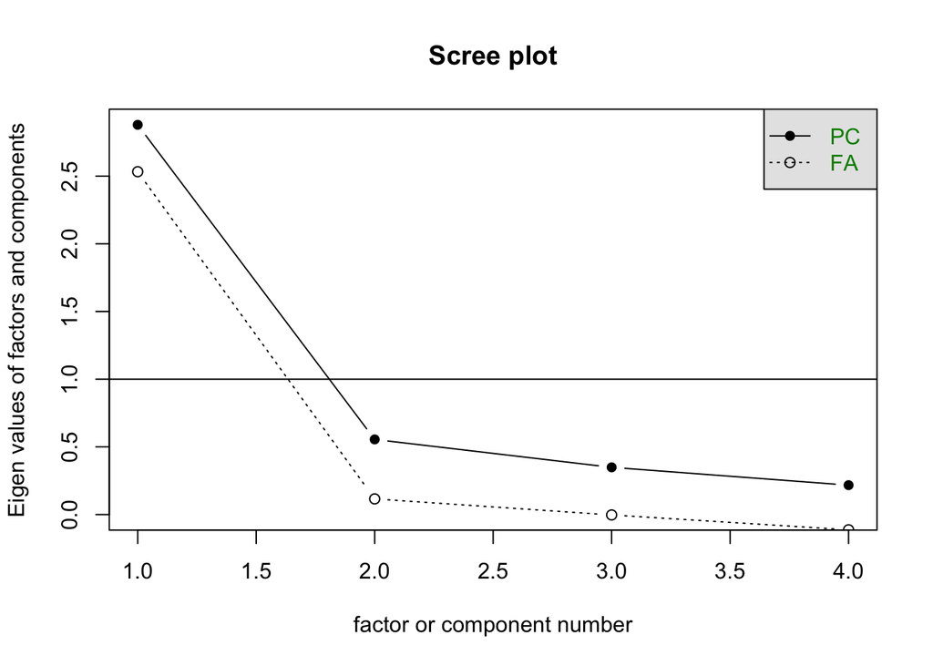

```r
# Scree plot shown in the video
psych::scree(employee_items)
```

The employee items should show one dominant factor with substantial positive loadings. The correlation-matrix first eigenvalue is about 2.879. Factor analysis and Cronbach’s alpha support treating Q3–Q6 as a common employee-proficiency measure, but they do not prove all aspects of validity.

# 11 Create a composite index

Because Q3–Q6 use the same 1–5 direction and show good reliability, I use `rowMeans()`. A respondent needs all four answers for the index in this version.

```r
analysis$employee_proficiency <- rowMeans(
  analysis |> select(q3, q4, q5, q6),
  na.rm = FALSE
)

# Describe the new scale
summary(analysis$employee_proficiency)
```

```
   Min. 1st Qu.  Median    Mean 3rd Qu.    Max.
  2.750   4.000   4.000   4.205   4.750   5.000
```

```r
sd(analysis$employee_proficiency, na.rm = TRUE)
```

```
[1] 0.5939604
```

```r
# Compare it with the employee performance index already in the raw file
all.equal(analysis$employee_proficiency,
          as.numeric(data_raw$employeeperformance))
```

```
[1] TRUE
```

The average employee-proficiency score should be approximately 4.205 out of 5, suggesting respondents generally evaluated employees positively. The original SPSS file already contains an employee performance variable; the comparison checks that our new calculation agrees with it.

# 12 Save the prepared data

I save the cleaned data into a new SPSS `.sav` file. I also save CSV frequency and codebook files for reference.

```r
dir.create("outputs", showWarnings = FALSE)

# Prepare labelled SPSS output with the updated questionnaire labels
prepared <- analysis
for (v in questions) {
  prepared[[v]] <- haven::labelled(
    analysis[[v]],
    labels = labelled::val_labels(data_labelled[[v]]),
    label = attr(data_labelled[[v]], "label")
  )
  # Add a clear variable description from the coding sheet
  attr(prepared[[v]], "label") <- question_description[match(v, questions)]
}

# Give the reversed columns the correct new value labels too
reverse_rate_labels <- c(
  "Very low" = 1, "Low" = 2, "Average" = 3,
  "High" = 4, "Very high" = 5
)
reverse_frequency_labels <- c(
  "Never" = 1, "Not often enough" = 2,
  "About right" = 3, "Very often" = 4, "Too often" = 5
)
reverse_accuracy_labels <- c(
  "Poor" = 1, "Fair" = 2, "Good" = 3, "Excellent" = 4
)
reverse_awareness_labels <- c(
  "Unaware" = 1, "Aware but not used" = 2,
  "Aware and have used" = 3
)
reverse_overall_labels <- c(
  "Very poor" = 1, "Poor" = 2, "Average" = 3,
  "Good" = 4, "Excellent" = 5
)

prepared <- prepared |>
  set_value_labels(
    q7r = reverse_rate_labels, q8r = reverse_rate_labels,
    q9r = reverse_frequency_labels, q10r = reverse_accuracy_labels,
    q13r = reverse_awareness_labels, q14r = reverse_awareness_labels,
    q15r = reverse_awareness_labels, q16r = reverse_awareness_labels,
    q17r = reverse_awareness_labels, q18r = reverse_awareness_labels,
    q19r = reverse_awareness_labels, q20r = reverse_awareness_labels,
    q21r = reverse_awareness_labels, q22r = reverse_awareness_labels,
    q23r = reverse_awareness_labels, q24r = reverse_awareness_labels,
    q25r = reverse_awareness_labels, q26r = reverse_awareness_labels,
    q37r = reverse_overall_labels, q12_clean = yes_no_labels
  )

# Describe the new variables in the prepared SPSS file
for (v in c("q7r", "q8r", "q9r", "q10r", paste0("q", 13:26, "r"), "q37r")) {
  old_question <- sub("r$", "", v)
  attr(prepared[[v]], "label") <- paste0(
    "Recoded: ", question_description[match(old_question, questions)]
  )
}
attr(prepared$q12_clean, "label") <- "Account confidentiality (no answer removed)"
attr(prepared$employee_proficiency, "label") <- "Employee proficiency (mean of Q3-Q6)"

# Save all original questions, new codes, and employee index
write_sav(prepared, "outputs/case31_prepared.sav")
write_csv(analysis, "outputs/case31_prepared.csv")
write_csv(codebook, "outputs/case31_codebook.csv")
write_csv(frequencies, "outputs/case31_frequencies.csv")

file.exists("outputs/case31_prepared.sav")
```

```
[1] TRUE
```

# 13 Summary

The SPSS dataset contains 128 provided responses. I checked questionnaire coding and measurement levels, added variable and response labels, screened incomplete and unusual responses without automatically excluding them, examined missing and invalid answers, reverse-coded the variables, ran frequency checks, and tested the employee-proficiency scale. Q3–Q6 have a Cronbach’s alpha of 0.866 and the calculated employee-proficiency mean is 4.205 on a five-point scale. I kept Q30–Q34 separate because their internal consistency is weaker.

# 14 Appendix

[GitHub Repository](https://github.com/Sheilaaa0312/Case31_Data_Preparation)

[GitHub Pages](https://sheilaaa0312.github.io/Case31_Data_Preparation/)